# Trabajo en clase # 1

Jose Aguilar, Eilyn Salazar, Crisia Piedra

1 de Junio, 2020

# Fase de entendimiento del negocio

## Determinar los objetivos de negocio

### Objetivos de negocio

1. Incrementar las ventas enfocándose en los mejores clientes.
2. Mejorar la planeacion de presupuestos mensuales a partir de los estimados de ventas a futuro.

### Criterios de éxito (en términos de negocio)

1. Identificar los 3 segmentos de mercado más rentables para la empresa a fin de orientar la estrategia de ventas.
2. Mejorar las estimaciones de ventas mensuales a un 20% de su valor real.

## Evaluación de la situación actual

Actualmente la compañía XYZ no cuenta con controles para estimar la demanda de los productos que ofrece a través de sus diferentes cadenas minoristas, esto produce que en ocasiones el inventario disponible sea insuficiente para cierto tipo de productos y en otras ocasiones haya exceso de existencias de otros, por esta razón desea optimizar la gestión de sus inventarios a partir de la información histórica disponible sobre las ventas de los diferentes productos que se comercializan.

Por otra parte, el departamento de mercadeo de la empresa desea optimizar su presupuesto enfocando sus esfuerzos en los clientes que son más rentables para la compañía para esto está considerando crear un programa de fidelidad, sin embargo no cuenta con información sobre el perfil de sus mejores clientes.

### Inventario de recursos(datos, personal, TI)

#### Datos

- Datos de ventas históricos de un año.

#### Personal

- 1 patrocinador del proyecto representando la gerencia.
- 1 experto del área de mercadeo para apoyar la estrategia del negocio.
- 1 analista de datos con conocimiento de los sistemas y fuentes de datos.
- 1 desarrollador.

#### TI

Un ambiente virtualizado en la nube con las siguientes características. * OS: Window Server 2016 * RAM: 32 GB * CPU: @2.4 GHz 2.39 GHz (8 processors)

#### Software

1. R y RStudio: Para análisis de datos.
2. MySQL y MySQL Workbench: Fuentes, almacenamiento de datos y herramientas de modelado y consulta.
3. Tableau: Visualización de datos
4. Notepad++ y Visual Studio Code: Desarrollo y revisión de logs de sistema.

### Requerimientos

#### Seguridad

- Solo la gerencia de mercadeo y la gerencia general tendrá acceso a los resultados de la investigación realizada.

#### Legales /Confidencialidad

- Considerando las políticas de confidencialidad y el manejo de los datos personales de los clientes, este proyecto no debe hacer uso de datos personales para su análisis.

#### Implementación y mantenimiento

- Considerando que se utilizará un ambiente virtualizado en la nube, se requiere el uso de VPNs para el acceso al área de desarrollo.
- Todos los equipos utilizados para el análisis deben contar con los parches de sistema operativo y antivirus actualizado.
- El despliegue de los resultados del modelo, y reportes generados se realizará mediante el uso de la herramienta Tableau.

#### Cronograma

- Se estima que la duración del proyecto no podrá exceder más de 1 mes.

### Supuestos

- Se cuenta con acceso a datos de ventas de 1 año.
- La compañía cuenta con los recursos técnicos para satisfacer los requerimientos técnicos del proyecto.
- El proyecto cuenta con la aprobación del negocio y el personal capacitado para ser desarrollado.

### Restricciones

- Solo se cuenta con 1 año de datos históricos.
- La información de clientes es limitada por motivos de privacidad.
- Ausencia de información sobre las categorías de cada producto.

### Riesgos y contingencias

```r
atributos<-read.csv('riesgos.csv', sep = ',',dec = '.')
kable(atributos[,0:3],caption = "Riesgos y Contingencias")%>%
kable_styling(bootstrap_options = c("striped", "hover"))
```

Riesgos y Contingencias

| Tipo.de.Riesgo | Riesgo | Estrategia.de.Contingencia |
| --- | --- | --- |
| Riesgos de Negocio | Cambios en el ambiente de negocio que sean contrarios al objetivo del proyecto. | Involucrar a las diferentes áreas e involucrados de la compañía en la toma de decisiones y presentación de avances del proyecto, para hacer los cambios o adaptaciones requeridos según la necesidad del… |
| Riesgos Organizacionales | Cambios organizacionales | Desarrollo de planes de continuidad del negocio que permitan documentar todo el proceso de desarrollo, documentar roles, responsabilidades y tareas para el manejo de personal de respaldo o backups en … |
|  | Salida de involucrados clave para la compañía. |  |
| Riesgos Financieros | Incremento en el costo estimado del proyecto. | Creación de un presupuesto extraordinario para el manejo de imprevistos financieros durante el proyecto. |
| Riesgos Técnicos | Herramientas seleccionadas para la implementación no cumplen las expectativas | Previo a la fase de implementación y desarrollo realizar una comparación de las herramientas a utilizar. |
| Riesgos de los datos | Datos limitados a 1 año de ventas | Diseñar una estrategia de mantenimiento de los datos, para la evaluación de los objetivos de forma anual. |
|  | Ausencia de datos de nuevos productos del mercado | Diseñar en conjunto con el analista de datos una estrategia de sincronización de los datos periódica para la inclusión de nuevos productos |

### Beneficios

- Reducción de gastos por almacenamiento de inventarios y evitar compras innecesarias.
- Mejora en la tasa de retención de clientes
- Incremento en las ganancias gracias a la mayor disponibilidad de inventario para los productos más vendidos.

## Determinar los objetivos de minería de datos

### Objetivos de minería de datos

- Identificar segmentos de mercados minoristas a partir de las ventas.
- Determinar los 3 segmentos de mercado que generan más ingresos.
- Predecir las ventas mensuales a partir de los datos históricos.

### Criterios de éxito (desde la perspectiva de minería de datos)

1. Identificar 3 clústeres de datos que permitan agrupar los diferentes clientes de la compañía pasado en su perfil.
2. Evaluar la precisión del modelo de predicción a fin de validar que la predicción se encuentre dentro de un 20% de las ventas reales.

##Plan del proyecto

### Evaluación inicial de herramientas y técnicas

Para el desarrollo de este proyecto se utilizará el lenguaje de programación R, y la herramienta RStudio a fin de realizar al proceso de exploración de los datos e identificar las librerías y técnicas de minería de datos más apropiadas para la realización del mismo.

Para el cumplimiento de los objetivos de mineria se utilizaran las técnicas de clustering K-means, y kmedoids, de igual manera para la predicción de las ventas se usara regresión lineal simple y múltiple.

### Plan del proyecto

Se debe señalar que la estimación inicial para el desarrollo del proyecto no debe de tardar más de 1 mes y por lo cual se consideran 24 días hábiles para la implementación del mismo, los cuales son distribuidos de la siguiente manera.

```r
atributos<-read.csv('plan_proyecto.csv', sep = ',',dec = '.',encoding = "UTF-8")
kable(atributos[,0:5],caption = "Plan de Proyecto")%>%
kable_styling(bootstrap_options = c("striped", "hover"))
```

Plan de Proyecto

Fases

Actividades

Riesgos

Contingencias

Recurso

Entendimiento del negocio

1. Determinar los objetivos del negocio
2. Evaluación de la situación
3. Determinar los objetivos de minería de datos
4. Generar el plan de proyecto.

Falta de disponibilidad de los involucrados. Objetivos definidos no alineados con las necesidades del negocio.

Validación de los objetivos con la gerencia ejecutiva de la compañía. Coordinación a través de conferencias y emails para establecer la fecha de inicio del proyecto. Milestones. Creación de un project roster para la ubicación de los involucrados y sus backups en caso de ser necesario.

Patrocinador Experto en la gerencia de mercadeo

Entendimiento de los datos

1. Recopilación inicial de datos

Describir los datos

Explorar los datos

Verificar la calidad de los datos

Ausencia de productos lanzados recientemente al mercado. Falta de conocimiento de negocio por parte del analista.

En conjunto con el analista de datos, realizar un proceso de verificación y recolección de los datos más recientes en el mercado. Trabajar de la mano con el experto en la gerencia de mercadeo y otros involucrados expertos en el manejo de los datos.

Experto en la gerencia de mercadeo Analista de datos Desarrollador

Preparación de los datos

1. Selección de los datos.

Limpiar los datos.

Construcción de datos

Integrar los datos

Ausencia de valores en múltiples columnas. Determinar las variables que analizar como parte del problema a resolver

Determinar la mejor técnica de imputación de datos, en conjunto con la gerencia de mercadeo. Uso de técnicas como análisis de correlación, análisis de componentes principales para identificar las variables más relevantes para el análisis.

Experto en la gerencia de mercadeo Analista de datos Desarrollador

Modelado

1. Seleccionar la técnica de modelado

Generar diseño de testing

Construir el modelo

Evaluar el modelo

Mal diseño en la implementación del modelo Las técnicas de minería seleccionados no proveen los resultados esperados La duración en la ejecución de los modelos y su entrenamiento tarda más de lo estimado

Uso de múltiples modelos al aplicar una misma técnica de minería. Uso de múltiples técnicas de minería.

Analista de datos Desarrollador

Evaluación

1. Evaluar los Resultados

Revisión del proceso

Determinar Pasos a Seguir

Insatisfacción de los involucrados con los resultados del proyecto

Aumento de las capacidades computacionales de los equipos en los que se realiza el proceso de entrenamiento. Replanteamiento de las metas y objetivos de la investigación con los involucrados del proyecto, añadiendo nuevas variables/datos adicionales

Experto en la gerencia de mercadeo Analista de datos Desarrollador

Implementación (Deployment)

1. Plan de despliegue

Plan de Monitoreo y mantenimiento

Producción del reporte final

Revisión del proyecto

Aumento en el costo de los recursos técnicos disponibles. Variación en el alcance del proyecto.

Comparación de proveedores que ofrecen servicios en la nube y se adecuen a las necesidades del proyecto. Establecimiento de una condición de cierre del proyecto y creación de un plan de administración para nuevas fases

Analista de datos Desarrollador

# Fase de entendimiento de los datos

## Recopilación inicial de datos

### Lista de datasets requeridos

Para el desarrollo de este trabajo se hará uso del conjunto de datos“Online Retail”. Este es un conjunto de datos transnacionales que contiene todas las transacciones que ocurren entre el 12/01/2010 y el 12/09/2011 para un minorista en línea registrado en el Reino Unido y sin tienda. La compañía vende principalmente regalos únicos para toda ocasión.

#### Ubicación de los datasets

Este conjunto de datos se encuentra disponible en el Machine Learning Repository a través del siguiente url.

#### Método de acceso

El conjunto de datos puede ser descargado en formato .xlsx a través del siguiente link http://archive.ics.uci.edu/ml/machine-learning-databases/00352/

## Descripción de los datos

```r
atributos<-read.csv('atributos.csv', sep = ',',dec = '.')
kable(atributos[,0:3],caption = "Descripción de atributos")%>%
kable_styling(bootstrap_options = c("striped", "hover"))
```

Descripción de atributos

| Variable | Descripción | Tipo |
| --- | --- | --- |
| InvoiceNo | Número de factura Nominal; un número integral de 6 dígitos asignado exclusivamente a cada transacción. Si este código comienza con la letra ‘c’; indica una cancelación. | Cualitativa Nominal (Alfanumérico) |
| StockCode | Código de producto (artículo). Nominal; un número integral de 5 dígitos asignado exclusivamente a cada producto distinto. | Cualitativa Nominal (Alfanumérico) |
| Description | Nombre del producto (artículo). Nominal. | Cualitativa Nominal (Alfanumérico) |
| Quantity | Las cantidades de cada producto (artículo) por transacción. Numérico. | Cuantitativa Continua (Numérico) |
| InvoiceDate | Fecha y hora de inicio. Numérico; el día y la hora en que se generó cada transacción. | Cuantitativa Discreta (Fecha) |
| UnitPrice | Precio unitario. Numérico; precio del producto por unidad en libras esterlinas. | Cuantitativa Continua (Numérico) |
| CustomerID | Número de cliente. Nominal; un número integral de 5 dígitos asignado exclusivamente a cada cliente. | Cualitativa Nominal (Alfanumérico) |
| Country | Nombre del país. Nominal; el nombre del país donde reside cada cliente. | Cualitativa Nominal (Alfanumérico) |

## Exploración de los datos

Se aplicó la función summary para la obtención de las estadísticas básicas de cada variable del conjunto de datos. Por medio de este análisis es posible observar elementos interesantes como los valores mínimos y máximos de las cantidades.

```r
retail<-read_excel("Online Retail.xlsx")
summary(retail)
```

```
##   InvoiceNo          StockCode         Description
##  Length:541909      Length:541909      Length:541909
##  Class :character   Class :character   Class :character
##  Mode  :character   Mode  :character   Mode  :character
##
##
##
##
##     Quantity          InvoiceDate                    UnitPrice
##  Min.   :-80995.00   Min.   :2010-12-01 08:26:00   Min.   :-11062.06
##  1st Qu.:     1.00   1st Qu.:2011-03-28 11:34:00   1st Qu.:     1.25
##  Median :     3.00   Median :2011-07-19 17:17:00   Median :     2.08
##  Mean   :     9.55   Mean   :2011-07-04 13:34:57   Mean   :     4.61
##  3rd Qu.:    10.00   3rd Qu.:2011-10-19 11:27:00   3rd Qu.:     4.13
##  Max.   : 80995.00   Max.   :2011-12-09 12:50:00   Max.   : 38970.00
##
##    CustomerID       Country
##  Min.   :12346    Length:541909
##  1st Qu.:13953    Class :character
##  Median :15152    Mode  :character
##  Mean   :15288
##  3rd Qu.:16791
##  Max.   :18287
##  NA's   :135080
```

En el summary podemos ver algunas cosas interesantes, como por ejempo:

- Se identifican posibles valores default para variables como quantity con -80995.00 - es un valor irreal para una cantidad, por lo que es posible que sea el valor por defecto de este campo, y se obtiene como el valor mínimo en ese campo.
- Otro de los detalles que logra observarse es como variables como CustomerID y Description tienen valores NA.

Nota: En el caso de description es posible observar líneas en blanco al revisar las observaciones.

Para efectos de la tarea se le dará prioridad a los siguientes campos:

- InvoiceNo: Sera utilizado para agrupar las compras.
- CustomerID: Sera utilizado para identificar los clientes que seran agrupados.
- Total: Campo derivado (ver siguiente sección) que facilitará los calculos de las ventas.
- InvoiceDay: Variable creada con la fecha del día de la compra

Nota:

Las siguiente variables son utilizadas para la creacion del campo Total, mas no seran utilizadas directamente.

- Quantity: Sera utilizado para determinar el conjunto de productos mas vendidos.
- UnitPrice: Sera utilizado para determinar, junto con Quantity. las ventas a predecir.

#### Compras de clientes

De estos datos y basado en estas observaciones prelminares es posible crear algunos campos adicionales que pueden ayudar a la hora de manipularlos. Para inciar, vamos a crear estos dos campos adicionales:

| Campo | Descripción | Tipo |
| --- | --- | --- |
| Total | Total de la compra del producto, resultado de multiplicar UnitPrice por Quantity | Numérico |
| InvoiceDay | Fecha de la compra sin la hora para sumarizar por día las compras | Fecha |

```r
retail$Total <- retail$UnitPrice * retail$Quantity
retail$InvoiceDay <- as.Date(format(retail$InvoiceDate,"%Y-%m-%d"))
```

Ademas podemos observar que existen variables que son actualmente hileras (strings) o numeros pero en realidad representan un factor, por lo que se realizan las siguientes conversiones para estas columnas:

| Campo | Conversión | Nuevo Tipo |
| --- | --- | --- |
| StockCode | Convertirlo a un factor | Factor |
| Description | Convertirlo a un factor | Factor |
| Country | Convertirlo a un factor | Factor |
| CustomerID | Convertirlo a un factor | Factor |

```r
retail$StockCode <- as.factor(retail$StockCode)
retail$Description <- as.factor(retail$Description)
retail$Country <- as.factor(retail$Country)
retail$CustomerID <- as.factor(retail$CustomerID)
```

Podemos revisar algunas de estas variables y como se relacionan. Por ejemplo, en el siguiente gráfico se muestra el resultado de la multiplicación de las variables *UnitPrice* y *Quantity* (variable *Total*) agrupadas por cliente, y se muestran las compras totales de los 10 primeros clientes de la tabla:

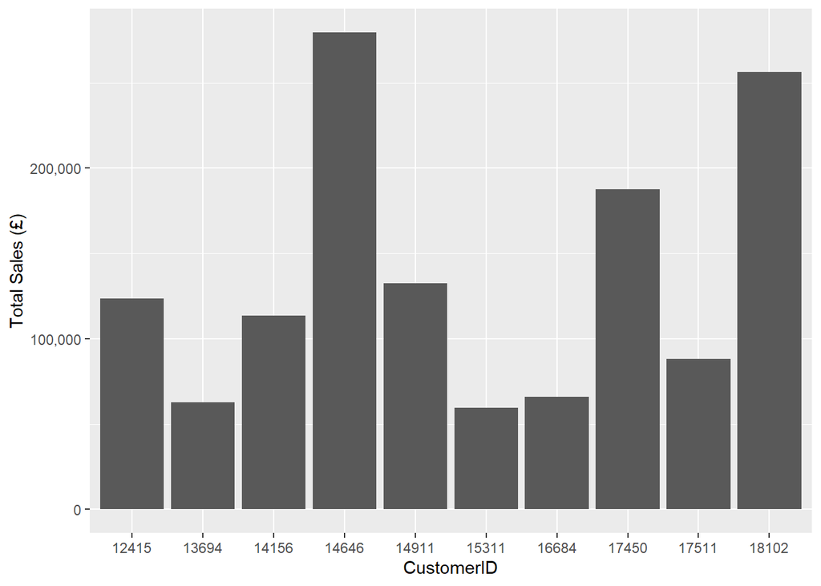

```r
por_cliente <- retail[!is.na(retail$CustomerID),] %>%
  group_by(CustomerID) %>%
  summarise_at(vars(Total),funs(sum(.))) %>%
  arrange(desc(Total))
pp<-ggplot(data=head(por_cliente,10), aes(x=CustomerID,y=Total)) +
  geom_bar(stat="identity") +
  scale_y_continuous(name="Total Sales (£)", labels = scales::comma)
pp
```

A través del customerID podemos ver las compras totales del cliente por ejemplo el cliente 14646 realizó compras totales por un monto de ￡279489 en 721 productos diferentes.

Podemos ver que productos compra:

```r
#Agrupamos por productos:
un_cliente_productos <- subset(retail, CustomerID==14646) %>%
  group_by(StockCode,Description) %>%
  summarise_at(vars(Quantity,Total),list(~sum(.))) %>%
  arrange(desc(Total))
un_cliente_totales<-sum(un_cliente_productos$Total)
un_cliente_productos_diferentes<-nrow(un_cliente_productos)
```

Las compras totales del cliente son:

```r
print(un_cliente_totales)
```

```
## [1] 279489
```

en la siguiente cantidad de productos:

```r
print(un_cliente_productos_diferentes)
```

```
## [1] 721
```

La siguiente tabla es una muestra de los productos que adquirió, la cantidad que adquirió y el total de la venta:

```r
kable(head(un_cliente_productos,10),"html", booktabs = T)%>%
kable_styling(latex_options = "striped")
```

| StockCode | Description | Quantity | Total |
| --- | --- | --- | --- |
| 23084 | RABBIT NIGHT LIGHT | 4801 | 9568.48 |
| 22326 | ROUND SNACK BOXES SET OF4 WOODLAND | 3120 | 7956.00 |
| 22629 | SPACEBOY LUNCH BOX | 4492 | 7415.40 |
| 22630 | DOLLY GIRL LUNCH BOX | 4096 | 6758.40 |
| 22328 | ROUND SNACK BOXES SET OF 4 FRUITS | 1584 | 4039.20 |
| 85099B | JUMBO BAG RED RETROSPOT | 2000 | 3468.00 |
| 21731 | RED TOADSTOOL LED NIGHT LIGHT | 2376 | 3459.60 |
| 22423 | REGENCY CAKESTAND 3 TIER | 288 | 3153.60 |
| 22243 | 5 HOOK HANGER RED MAGIC TOADSTOOL | 2016 | 2923.20 |
| 20712 | JUMBO BAG WOODLAND ANIMALS | 1500 | 2629.00 |

Podemos ver que algunos clientes compran grandes cantidades - por ejemplo en este caso, el cliente compró 4801 unidades del producto RABBIT NIGHT LIGHT. Esto nos hace pensar que algunas de las cantidades grandes vistas anterioremente no son anómalas.

Los siguientes gráficos muestran el comportamiento de las ventas en el tiempo, así como la agrupación por país.

Para observar las ventas por día, utilizamos la variable InvoiceDay, con el fin de eliminar la hora de la venta que no es de interés para este análisis.

```r
invoices <- retail %>%
  group_by(InvoiceDay) %>%
  summarise_at(vars(Total),funs(sum(.)))
kable(head(invoices,10),"html", booktabs = T)%>%
  kable_styling(latex_options = "striped")
```

| InvoiceDay | Total |
| --- | --- |
| 2010-12-01 | 58635.56 |
| 2010-12-02 | 46207.28 |
| 2010-12-03 | 45620.46 |
| 2010-12-05 | 31383.95 |
| 2010-12-06 | 53860.18 |
| 2010-12-07 | 45059.05 |
| 2010-12-08 | 44189.84 |
| 2010-12-09 | 52532.13 |
| 2010-12-10 | 57404.91 |
| 2010-12-12 | 17240.92 |

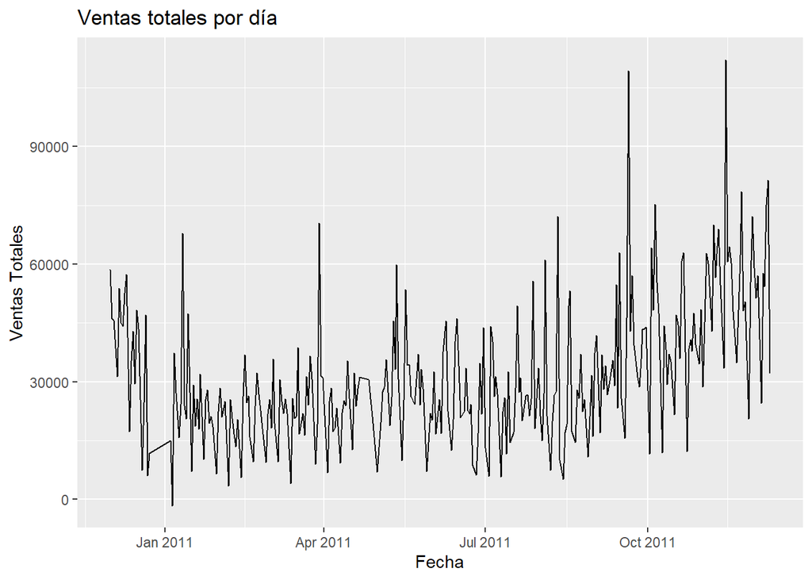

```r
p <- ggplot(invoices, aes(x=InvoiceDay, y=Total)) +
  geom_line() +
  xlab("Fecha") +
  ylab("Ventas Totales") +
  ggtitle("Ventas totales por día")
p
```

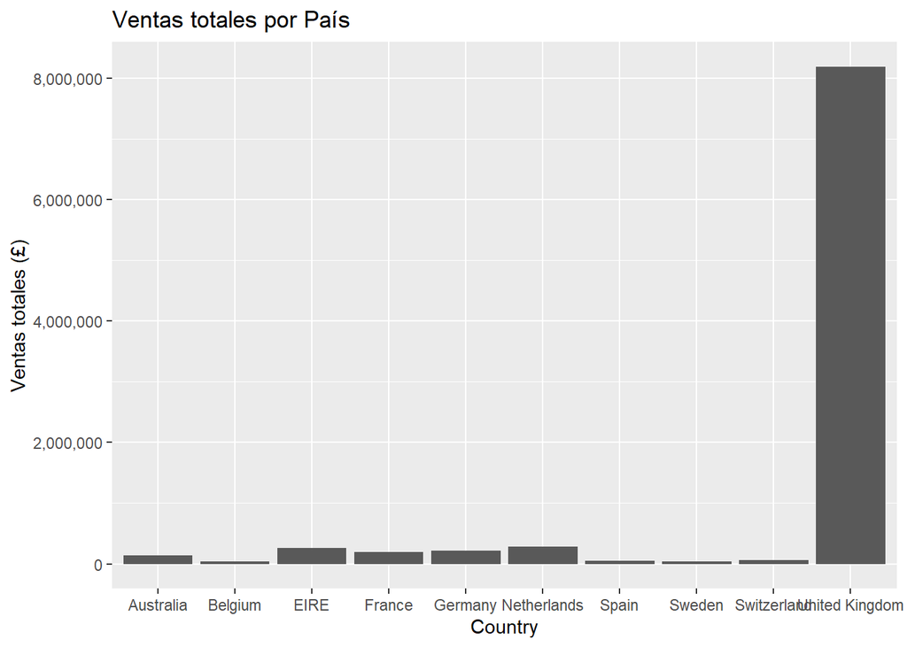

```r
por_pais <- retail %>%
  group_by(Country) %>%
  summarise_at(vars(Total),funs(sum(.))) %>%
  arrange(desc(Total))
pp<-ggplot(data=head(por_pais,10), aes(x=Country,y=Total)) +
  geom_bar(stat="identity") +
  scale_y_continuous(name="Ventas totales (£)", labels = scales::comma) +
  ggtitle("Ventas totales por País")
pp
```

Y podemos ademas observar las cantidades de las ventas por país:

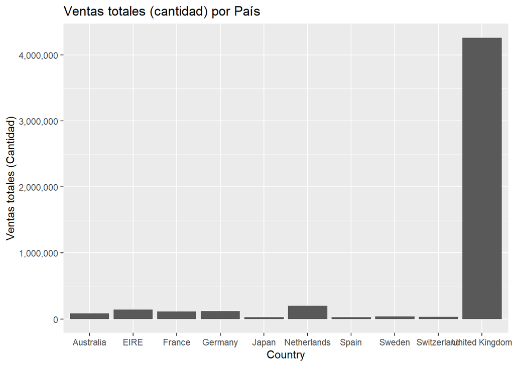

```r
por_cantidad <- retail %>%
  group_by(Country) %>%
  summarise_at(vars(Quantity),funs(sum(.))) %>%
  arrange(desc(Quantity))
pp<-ggplot(data=head(por_cantidad,10), aes(x=Country,y=Quantity)) +
  geom_bar(stat="identity") +
  scale_y_continuous(name="Ventas totales (Cantidad)", labels = scales::comma) +
  ggtitle("Ventas totales (cantidad) por País")
pp
```

## Verificación de la calidad de datos

Uno de los problemas de calidad detectados es el gran número de observaciones en donde el CustomerID tiene un valor NA, es decir no se tiene la información de cuáles fueron los clientes que realizaron las compras, lo cual puede influir en el análisis a realizar al no contar con esta información.

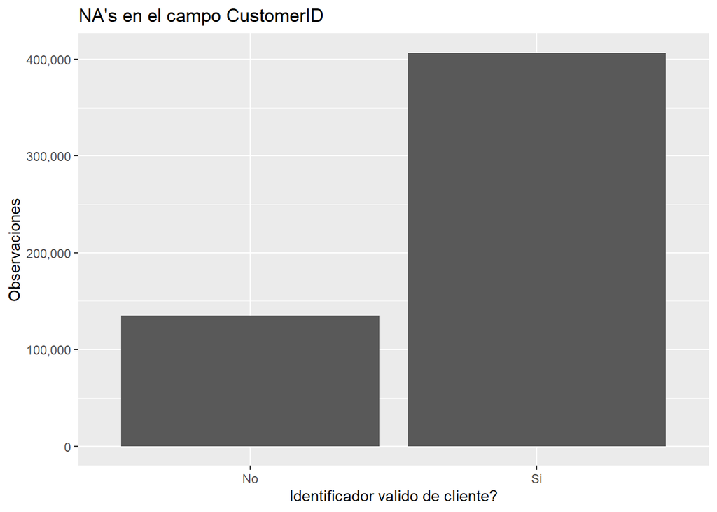

```r
numclientesna <- count(is.na(retail$CustomerID))
library(ggplot2)
tmp_clientes<-data.frame(IdValido=c("Si", "No"), conteo=c(numclientesna[1,2],numclientesna[2,2]), index=1)
ggplot(tmp_clientes,aes(IdValido,conteo)) +
  geom_col(stat="identity")+
  scale_y_continuous(name="Observaciones", labels = scales::comma) +
  labs(x="Identificador valido de cliente?")+
  ggtitle("NA's en el campo CustomerID")
```

Como se puede observar, hay 135080 NA - estos registros no pueden ser utilizados para el analisis de clientes a realizar, dejandonos solamente con los 406829 registros restantes.

Así mismo al analizar las variables de quantity y unit price, es posible ver que existen datos que a simple vista son anómalos como se muestra en las siguientes gráficas de caja.

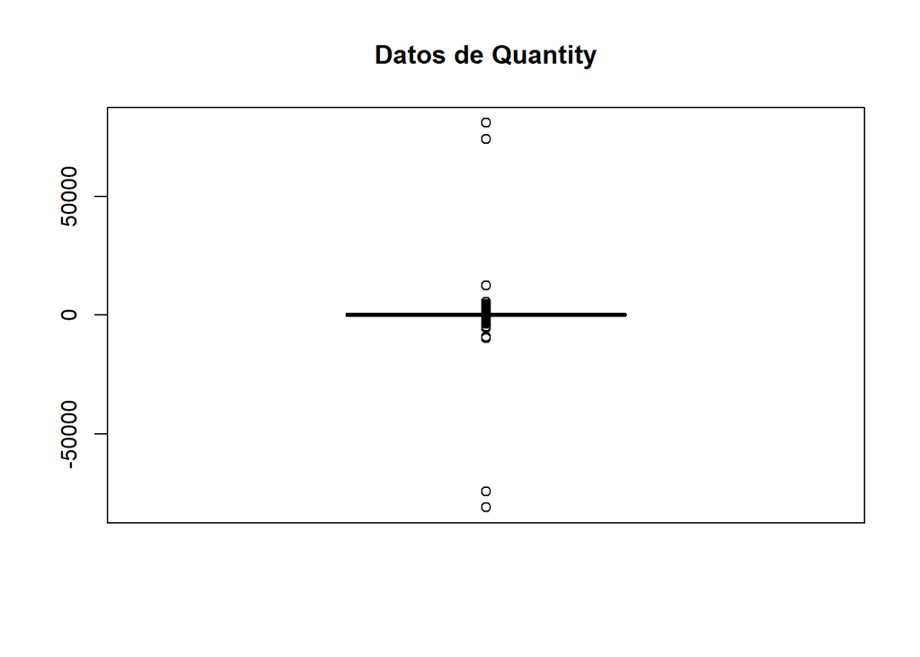

```r
boxplot(retail$Quantity,data=retail,main="Datos de Quantity")
```

De acuerdo con esto, existen 58619 valores “outliers”. Dado que representa un número importante de valores es importante validar estos datos con el experto del negocio a fin de comprender su validez y de no ser completamente correcto, será necesario imputarlos de alguna forma - sin embargo, hay que tener cuidado dado que puede alterar significativamente los resultados.

Podemos hacer el mismo estudio con el campo UnitPrice

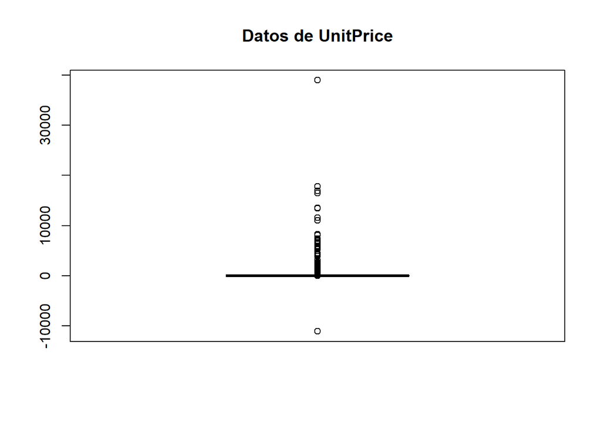

```r
boxplot(retail$UnitPrice,data=retail,main="Datos de UnitPrice")
```

De acuerdo con esto, existen 39627 valores “outliers” para UnitPrice. En este caso debemos hacer un tratamiento similar para los valores de la variable quantity.

Adicionalmente podemos revisar para los valores que representan montos de dinero (UnitPrice) o Cantidades, que los valores tengan sentido - podemos revisar por ejemplo que sean positivos:

Para Unit Price:

```r
UnitPrice_Positivos<- nrow(retail[retail$UnitPrice >= 0,])
UnitPrice_Positivos
```

```
## [1] 541907
```

```r
UnitPrice_Negativos<- nrow(retail[retail$UnitPrice < 0,])
UnitPrice_Negativos
```

```
## [1] 2
```

```r
kable(head(retail[retail$UnitPrice < 0,],10),"html", booktabs = T)%>%
  kable_styling(latex_options = "striped")
```

| InvoiceNo | StockCode | Description | Quantity | InvoiceDate | UnitPrice | CustomerID | Country | Total | InvoiceDay |
| --- | --- | --- | --- | --- | --- | --- | --- | --- | --- |
| A563186 | B | Adjust bad debt | 1 | 2011-08-12 14:51:00 | -11062.06 | NA | United Kingdom | -11062.06 | 2011-08-12 |
| A563187 | B | Adjust bad debt | 1 | 2011-08-12 14:52:00 | -11062.06 | NA | United Kingdom | -11062.06 | 2011-08-12 |

Podemos ver que solamente son dos valores negativos, y que por la descripcion que tienen, probablemente pueden ser ignorados.

Para Quantity:

```r
Quantity_Positivos<- nrow(retail[retail$Quantity >= 0,])
Quantity_Positivos
```

```
## [1] 531285
```

```r
Quantity_Negativos<- nrow(retail[retail$Quantity < 0,])
Quantity_Negativos
```

```
## [1] 10624
```

```r
kable(head(retail[retail$Quantity < 0,]),"html", booktabs = T)%>%
  kable_styling(latex_options = "striped")
```

| InvoiceNo | StockCode | Description | Quantity | InvoiceDate | UnitPrice | CustomerID | Country | Total | InvoiceDay |
| --- | --- | --- | --- | --- | --- | --- | --- | --- | --- |
| C536379 | D | Discount | -1 | 2010-12-01 09:41:00 | 27.50 | 14527 | United Kingdom | -27.50 | 2010-12-01 |
| C536383 | 35004C | SET OF 3 COLOURED FLYING DUCKS | -1 | 2010-12-01 09:49:00 | 4.65 | 15311 | United Kingdom | -4.65 | 2010-12-01 |
| C536391 | 22556 | PLASTERS IN TIN CIRCUS PARADE | -12 | 2010-12-01 10:24:00 | 1.65 | 17548 | United Kingdom | -19.80 | 2010-12-01 |
| C536391 | 21984 | PACK OF 12 PINK PAISLEY TISSUES | -24 | 2010-12-01 10:24:00 | 0.29 | 17548 | United Kingdom | -6.96 | 2010-12-01 |
| C536391 | 21983 | PACK OF 12 BLUE PAISLEY TISSUES | -24 | 2010-12-01 10:24:00 | 0.29 | 17548 | United Kingdom | -6.96 | 2010-12-01 |
| C536391 | 21980 | PACK OF 12 RED RETROSPOT TISSUES | -24 | 2010-12-01 10:24:00 | 0.29 | 17548 | United Kingdom | -6.96 | 2010-12-01 |

Para las cantidades se puede observar que son muchos mas, 10624. Es necesario revisar esto con los analistas del negocio. Sin embargo el hecho que una de las descripciones tenga el texto “Discount” nos hace pensar que tal vez sean por proceso de negocios - una forma de dar descuentos o de realizar devoluciones de productos.

# Fase de preparación de los datos

## Selección de datos:

Debe describir y justificar con cuáles atributos trabajará o bien cuáles serán descartados, de igual forma, si se realiza una selección por filas, debe estar documentada y justificada.

Para efectos de este trabajo solo se utilizaran datos del pais “Germany”

```r
datos_ge <- retail[retail$Country == 'Germany',]
summary(datos_ge)
```

```
##   InvoiceNo           StockCode
##  Length:9495        POST   : 383
##  Class :character   22326  : 120
##  Mode  :character   22423  :  81
##                     22328  :  78
##                     22554  :  67
##                     20719  :  59
##                     (Other):8707
##                              Description      Quantity
##  POSTAGE                           : 383   Min.   :-288.00
##  ROUND SNACK BOXES SET OF4 WOODLAND: 120   1st Qu.:   5.00
##  REGENCY CAKESTAND 3 TIER          :  81   Median :  10.00
##  ROUND SNACK BOXES SET OF 4 FRUITS :  78   Mean   :  12.37
##  PLASTERS IN TIN WOODLAND ANIMALS  :  67   3rd Qu.:  12.00
##  WOODLAND CHARLOTTE BAG            :  59   Max.   : 600.00
##  (Other)                           :8707
##   InvoiceDate                    UnitPrice         CustomerID
##  Min.   :2010-12-01 13:04:00   Min.   :  0.000   12471  : 531
##  1st Qu.:2011-04-04 12:10:00   1st Qu.:  1.250   12621  : 474
##  Median :2011-07-19 15:55:00   Median :  1.950   12474  : 457
##  Mean   :2011-07-03 14:23:10   Mean   :  3.967   12472  : 391
##  3rd Qu.:2011-10-11 12:38:00   3rd Qu.:  3.750   12720  : 359
##  Max.   :2011-12-09 12:16:00   Max.   :599.500   12705  : 348
##                                                  (Other):6935
##       Country         Total           InvoiceDay
##  Germany  :9495   Min.   :-599.50   Min.   :2010-12-01
##  Australia:   0   1st Qu.:  11.10   1st Qu.:2011-04-04
##  Austria  :   0   Median :  16.60   Median :2011-07-19
##  Bahrain  :   0   Mean   :  23.35   Mean   :2011-07-03
##  Belgium  :   0   3rd Qu.:  23.40   3rd Qu.:2011-10-11
##  Brazil   :   0   Max.   : 876.00   Max.   :2011-12-09
##  (Other)  :   0
```

### Selección de variables clave

- Quantity: Es la variable que nos indica cuales son las existencias que deben existir por cada producto para mejorar las existencias en inventarios basado en las ventas registradas.
- Unit Price: En conjunto con la variable quantity nos permite realizar el cálculo del valor monetario de las ventas realizadas por cliente.
- CustomerID: Nos permite agrupar las compras realizadas por el mismo cliente, esto con el fin de identificar cuáles son los mejores clientes de la compañía.
- Country: Nos permite analizar o agrupar el comportamiento de las compras por país.
- Total: Total es una variable derivada y nos permite obtener el monto total de las compras realizadas por cliente, para analizar cuales son los mejores clientes basados en las mismas.
- InvoiceDay: Se empleara el InvoiceDate para realizar la creacion de variables adicionales asociadas a la dimensión tiempo, como la “frescura” y frecuencia de las compras realizadas por los clientes.

Dado que el dataset solamente contiene 8 campos, no se descartará ninguna variable. Sin embargo si se evaluará descartar observaciones que presenten problemas como los outliers que se describen en la sección de Calidad de datos.

## Limpieza de datos

Basados en lo observado en la seccion de *Calidad de Datos*, podemos eliminar ciertos registros que son aportan a los modelos a realizar.

*Valores negativos en UnitPrice*

```r
kable(head(datos_ge[datos_ge$UnitPrice < 0,],10),"html", booktabs = T)%>%
  kable_styling(latex_options = "striped")
```

| InvoiceNo | StockCode | Description | Quantity | InvoiceDate | UnitPrice | CustomerID | Country | Total | InvoiceDay |
| --- | --- | --- | --- | --- | --- | --- | --- | --- | --- |

```r
retail <- datos_ge[!(datos_ge$UnitPrice < 0),]
kable(head(datos_ge[datos_ge$UnitPrice < 0,],10),"html", booktabs = T)%>%
  kable_styling(latex_options = "striped")
```

| InvoiceNo | StockCode | Description | Quantity | InvoiceDate | UnitPrice | CustomerID | Country | Total | InvoiceDay |
| --- | --- | --- | --- | --- | --- | --- | --- | --- | --- |

*Valores negativos en Quantity*

Asimismo se observaron varios valores negativos en el campo Quantity que corresponden a devoluciones y consideran que este parametro no sera utilizado, se proce a removerlas del conjunto de observaciones:

```r
kable(head(datos_ge[datos_ge$Quantity < 0,]),"html", booktabs = T)%>%
  kable_styling(latex_options = "striped")
```

| InvoiceNo | StockCode | Description | Quantity | InvoiceDate | UnitPrice | CustomerID | Country | Total | InvoiceDay |
| --- | --- | --- | --- | --- | --- | --- | --- | --- | --- |
| C536548 | 22244 | 3 HOOK HANGER MAGIC GARDEN | -4 | 2010-12-01 14:33:00 | 1.95 | 12472 | Germany | -7.80 | 2010-12-01 |
| C536548 | 22242 | 5 HOOK HANGER MAGIC TOADSTOOL | -5 | 2010-12-01 14:33:00 | 1.65 | 12472 | Germany | -8.25 | 2010-12-01 |
| C536548 | 20914 | SET/5 RED RETROSPOT LID GLASS BOWLS | -1 | 2010-12-01 14:33:00 | 2.95 | 12472 | Germany | -2.95 | 2010-12-01 |
| C536548 | 22892 | SET OF SALT AND PEPPER TOADSTOOLS | -7 | 2010-12-01 14:33:00 | 1.25 | 12472 | Germany | -8.75 | 2010-12-01 |
| C536548 | 22654 | DELUXE SEWING KIT | -1 | 2010-12-01 14:33:00 | 5.95 | 12472 | Germany | -5.95 | 2010-12-01 |
| C536548 | 22767 | TRIPLE PHOTO FRAME CORNICE | -2 | 2010-12-01 14:33:00 | 9.95 | 12472 | Germany | -19.90 | 2010-12-01 |

```r
datos_ge <- datos_ge[!(datos_ge$Quantity < 0),]
kable(head(datos_ge[datos_ge$Quantity < 0,],10),"html", booktabs = T)%>%
  kable_styling(latex_options = "striped")
```

| InvoiceNo | StockCode | Description | Quantity | InvoiceDate | UnitPrice | CustomerID | Country | Total | InvoiceDay |
| --- | --- | --- | --- | --- | --- | --- | --- | --- | --- |

*Eliminación de Observaciones con valores NA*

Al analizar el conjunto de datos se observa que hay algunas observaciones con valores NA en las columnas CustomerID y descripción las cuales son eliminadas.

```r
datos_ge <- datos_ge %>% drop_na(CustomerID, Description)
```

*Manejo de Outliers*

Para revisar los Outliers detectados en la sección de calidad de datos, se ejecuta un summary con el fin de determinar el mínimo, maximo, y otras caracteristicas de las columnas Quantity y UnitPrice:

```r
summary(datos_ge)
```

```
##   InvoiceNo           StockCode
##  Length:9042        POST   : 374
##  Class :character   22326  : 113
##  Mode  :character   22328  :  72
##                     22554  :  64
##                     22423  :  63
##                     20719  :  58
##                     (Other):8298
##                              Description      Quantity
##  POSTAGE                           : 374   Min.   :  1.00
##  ROUND SNACK BOXES SET OF4 WOODLAND: 113   1st Qu.:  6.00
##  ROUND SNACK BOXES SET OF 4 FRUITS :  72   Median : 10.00
##  PLASTERS IN TIN WOODLAND ANIMALS  :  64   Mean   : 13.19
##  REGENCY CAKESTAND 3 TIER          :  63   3rd Qu.: 12.00
##  WOODLAND CHARLOTTE BAG            :  58   Max.   :600.00
##  (Other)                           :8298
##   InvoiceDate                    UnitPrice         CustomerID
##  Min.   :2010-12-01 13:04:00   Min.   :  0.000   12621  : 467
##  1st Qu.:2011-04-08 09:54:00   1st Qu.:  1.250   12471  : 460
##  Median :2011-07-20 14:38:00   Median :  1.950   12474  : 424
##  Mean   :2011-07-05 04:34:40   Mean   :  3.708   12720  : 354
##  3rd Qu.:2011-10-11 12:38:00   3rd Qu.:  3.750   12472  : 339
##  Max.   :2011-12-09 12:16:00   Max.   :599.500   12705  : 334
##                                                  (Other):6664
##       Country         Total          InvoiceDay
##  Germany  :9042   Min.   :  0.00   Min.   :2010-12-01
##  Australia:   0   1st Qu.: 12.75   1st Qu.:2011-04-08
##  Austria  :   0   Median : 17.00   Median :2011-07-20
##  Bahrain  :   0   Mean   : 25.31   Mean   :2011-07-04
##  Belgium  :   0   3rd Qu.: 23.40   3rd Qu.:2011-10-11
##  Brazil   :   0   Max.   :876.00   Max.   :2011-12-09
##  (Other)  :   0
```

## Construcción de nuevos datos

Para ambos modelos a construir se crearon nuevos datos basados en la información disponible.

Para los modelos de clustering, se crearon las siguientes variables a através de la función RFM (https://cran.r-project.org/web/packages/rfm/rfm.pdf)

- date_most_recent: fecha de la compras más reciente del cliente
- recency_days: muestra que tan reciente es la ultima compra de un cliente. Es la diferencia en dias, de las ultima fecha analizada, con la fecha de la última compra.
- transaction_count: que es la cantidad de compras o transacciones realizadas por el cliente
- Amount: el total del valor monetario de las compras del cliente
- recency_score: puntaje de antigüedad del cliente
- frequency_score: puntaje de frecuencia del cliente
- monetary_score: puntaje monetario del cliente
- rfm_score: puntaje RFM del cliente

Para el modelo de regresión se crearon 13 variables nuevas:

- diff: diferencia del monto vendido entre la fecha y la fecha del mes anterior
- lag: 12 variables de lag distribuidas a lo largo de los 13 meses, que contienen las diferencias entre las ventas distribuidas a lo largo de todos los meses.

## Transformaciones aplicadas

Para los modelos de clustering, se realizaron agrupaciones de los datos por cliente y por fecha, sumarizando las variables Total y el conteo de las compras realizadas por el cliente.

En el caso de los modelos de regresion, se agruparon los datos por fecha, sumarizando el total de ventas para esa fecha.

### Agrupamiento por Fecha

Se agrupan las compras de los clientes por fecha.

```r
historic_invoices <- datos_ge %>%
  group_by(InvoiceDay,CustomerID) %>%
  summarise_at(vars(Total),funs(sum(.)))
kable(head(historic_invoices,10),"html", booktabs = T)%>%
  kable_styling(latex_options = "striped")
```

| InvoiceDay | CustomerID | Total |
| --- | --- | --- |
| 2010-12-01 | 12662 | 261.48 |
| 2010-12-02 | 12738 | 155.35 |
| 2010-12-03 | 12427 | 303.50 |
| 2010-12-03 | 12600 | 76.50 |
| 2010-12-03 | 12712 | 175.53 |
| 2010-12-05 | 12472 | 1631.30 |
| 2010-12-05 | 12647 | 372.00 |
| 2010-12-05 | 12720 | 473.39 |
| 2010-12-06 | 12708 | 196.44 |
| 2010-12-07 | 12647 | 596.80 |

# Fase de Modelado

## Selección de las técnicas a utilizar

Para cubrir los objetivos planteados, se seleccionaron dos técnicas de aprendizaje automático - clustering y regresión. A continuación se detallan ambas técnicas.

### Clustering de clientes

Para realizar el clustering esta tarea se hará uso de las técnicas de agrupamiento Kmedoids y Kmedias a fin de comprar los resultados de ambas técnicas usando diferentes parámetros de K.

### Regresión para la predicción del total de ventas.

Para el cumplimiento del objectivo de mineria “Predecir las ventas mensuales por producto a partir de los datos históricos” se hará uso de la técnica de regresión lineal simple.

## Construcción de modelos

### Modelos de agrupamiento

Se procede a crear las varias Recency, Frecuency y Monetary

```r
# Se procede a obtener la fecha de la ultima compra.
ultima_compra <- historic_invoices %>%
  group_by(CustomerID) %>%
  summarise_at(vars(InvoiceDay),funs(max(.)))
kable(head(ultima_compra,10),"html", booktabs = T)%>%
  kable_styling(latex_options = "striped")
```

| CustomerID | InvoiceDay |
| --- | --- |
| 12426 | 2011-05-29 |
| 12427 | 2011-11-18 |
| 12468 | 2011-06-05 |
| 12471 | 2011-12-07 |
| 12472 | 2011-11-07 |
| 12473 | 2011-11-10 |
| 12474 | 2011-11-22 |
| 12475 | 2011-10-17 |
| 12476 | 2011-11-24 |
| 12477 | 2011-11-17 |

```r
colnames(ultima_compra)= c('CustomerID','UltimaCompra')
```

Validamos que todos los clientes fueron considerados:

```r
length(unique(historic_invoices$CustomerID))
```

```
## [1] 94
```

```r
length(unique(ultima_compra$CustomerID))
```

```
## [1] 94
```

```r
visitas_por_cliente <- historic_invoices %>%
  group_by(CustomerID) %>%
  summarise_at(vars(InvoiceDay),funs(n_distinct(.)))
colnames(visitas_por_cliente)<- c('CustomerID','CantidadVisitas')
kable(head(visitas_por_cliente,10),"html", booktabs = T)%>%
  kable_styling(latex_options = "striped")
```

| CustomerID | CantidadVisitas |
| --- | --- |
| 12426 | 1 |
| 12427 | 3 |
| 12468 | 2 |
| 12471 | 20 |
| 12472 | 7 |
| 12473 | 4 |
| 12474 | 17 |
| 12475 | 1 |
| 12476 | 10 |
| 12477 | 6 |

```r
length(unique(visitas_por_cliente$CustomerID))
```

```
## [1] 94
```

Total de ventas por cliente

```r
#historic_invoices
#datos <- merge(historic_invoices, ultima_compra, by="CustomerID")
#datos2 <- merge(datos, visitas_por_cliente, by="CustomerID")
#head(datos)
#head(datos2)

total_por_cliente <- historic_invoices  %>%
  group_by(CustomerID) %>%
  summarise_at(vars(Total),funs(sum(.)))
kable(head(total_por_cliente,10),"html", booktabs = T)%>%
  kable_styling(latex_options = "striped")
```

| CustomerID | Total |
| --- | --- |
| 12426 | 582.73 |
| 12427 | 825.80 |
| 12468 | 729.54 |
| 12471 | 19824.05 |
| 12472 | 6572.11 |
| 12473 | 3938.55 |
| 12474 | 7375.79 |
| 12475 | 723.38 |
| 12476 | 6816.42 |
| 12477 | 13219.74 |

```r
length(unique(total_por_cliente$CustomerID))
```

```
## [1] 94
```

Calculamos la frescura de cada cliente:

```r
#Se calcula la recency
#datos['Recency'] <- as.numeric(difftime(datos$UltimaCompra ,datos$InvoiceDay , units = c("days")))
ultima_compra$Recency <- as.numeric(difftime(max(ultima_compra$UltimaCompra) ,ultima_compra$UltimaCompra , units = c("days")))
head(ultima_compra)
```

```
## # A tibble: 6 x 3
##   CustomerID UltimaCompra Recency
##   <fct>      <date>         <dbl>
## 1 12426      2011-05-29       194
## 2 12427      2011-11-18        21
## 3 12468      2011-06-05       187
## 4 12471      2011-12-07         2
## 5 12472      2011-11-07        32
## 6 12473      2011-11-10        29
```

```r
summary(ultima_compra)
```

```
##    CustomerID  UltimaCompra           Recency
##  12426  : 1   Min.   :2010-12-02   Min.   :  0.00
##  12427  : 1   1st Qu.:2011-09-08   1st Qu.: 16.25
##  12468  : 1   Median :2011-11-08   Median : 30.50
##  12471  : 1   Mean   :2011-09-22   Mean   : 77.12
##  12472  : 1   3rd Qu.:2011-11-22   3rd Qu.: 92.00
##  12473  : 1   Max.   :2011-12-09   Max.   :372.00
##  (Other):88
```

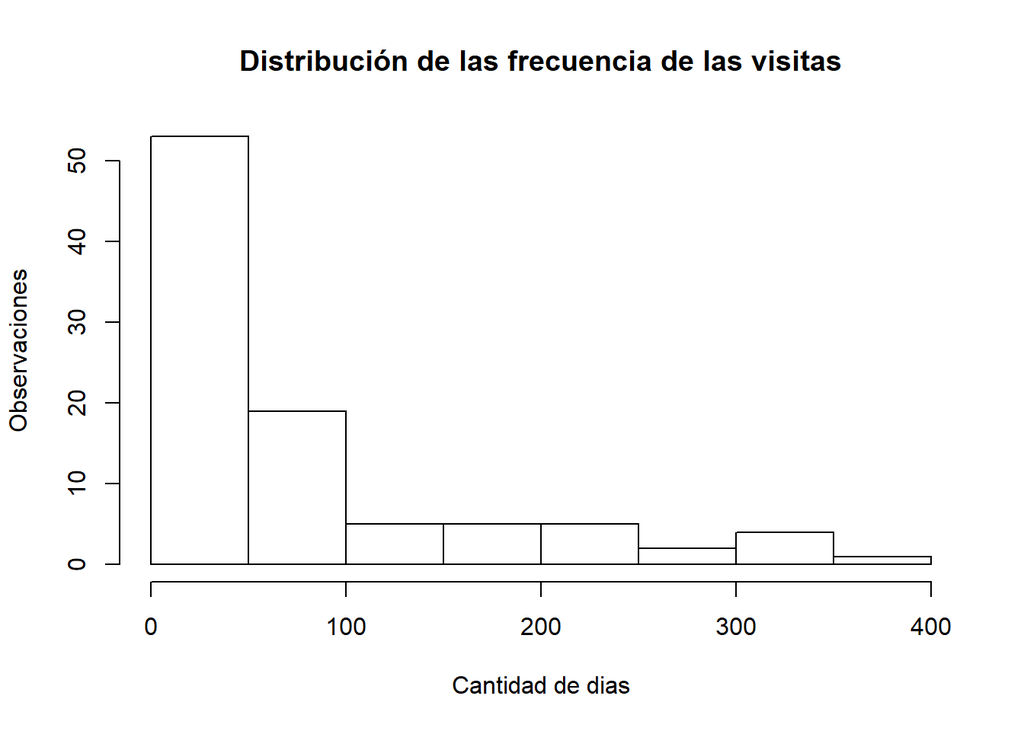

```r
hist(ultima_compra$Recency,
        main = 'Distribución de las frecuencia de las visitas',
        ylab = 'Observaciones',
        xlab = 'Cantidad de dias')
```

```r
datos <-  merge(ultima_compra, visitas_por_cliente, by="CustomerID")
datos <- merge(datos,total_por_cliente, by="CustomerID")
head(datos)
```

```
##   CustomerID UltimaCompra Recency CantidadVisitas    Total
## 1      12426   2011-05-29     194               1   582.73
## 2      12427   2011-11-18      21               3   825.80
## 3      12468   2011-06-05     187               2   729.54
## 4      12471   2011-12-07       2              20 19824.05
## 5      12472   2011-11-07      32               7  6572.11
## 6      12473   2011-11-10      29               4  3938.55
```

```r
analysis_date <- lubridate::as_date("2006-12-31", tz = "UTC")
rfm_result <- rfm_table_order(datos,
                              customer_id=CustomerID,
                              order_date=UltimaCompra,
                              revenue=Total, max(datos$UltimaCompra))
#summary(rfm_result)
rfm_result
```

```
## # A tibble: 94 x 9
##    customer_id date_most_recent recency_days transaction_cou~ amount
##    <fct>       <date>                  <dbl>            <dbl>  <dbl>
##  1 12426       2011-05-29                194                1   583.
##  2 12427       2011-11-18                 21                1   826.
##  3 12468       2011-06-05                187                1   730.
##  4 12471       2011-12-07                  2                1 19824.
##  5 12472       2011-11-07                 32                1  6572.
##  6 12473       2011-11-10                 29                1  3939.
##  7 12474       2011-11-22                 17                1  7376.
##  8 12475       2011-10-17                 53                1   723.
##  9 12476       2011-11-24                 15                1  6816.
## 10 12477       2011-11-17                 22                1 13220.
## # ... with 84 more rows, and 4 more variables: recency_score <int>,
## #   frequency_score <int>, monetary_score <int>, rfm_score <dbl>
```

##### Construcción del modelo #1 (Kmedoids)

Para el modelo #1 se hace uso de la técnica Kmedoids.

Para realizar la segmentación de cliente se empleará el análisis RFM para tratar crear variables adicionales, y tratar de agrupar a los clientes según sus caracteristicas.

RFM significa Frescura(Recency) - Frecuencia - Valor monetario. Para efectos del trabajo se intentará identificar si es posible agrupar a los clientes de la compañia analizada en las siguientes categorias.

- Valor bajo: clientes que son menos activos que otros, no son compradores o visitantes muy frecuentes y generan ingresos muy bajos, cero, tal vez negativos.
- Valor medio: en el medio de todo. A menudo, utilizando nuestra plataforma (pero no tanto como nuestros valores altos), es bastante frecuente y genera ingresos moderados.
- Alto valor: el grupo que no queremos perder. Alto ingreso, frecuencia y baja inactividad.

##### Selección de los parámetros modelo #1 (Kmedoids)

*Determinar los clusters optimos*

Para la selecion del numero optimo de clusters a crear, utilizamos 3 técnicas:

- Silhoutte
- Método del codo
- Estadística Gap

A continuación se muestran los resultados de estas técnicas:

```r
rfm_clustering<-rfm_result$rfm[,c("recency_days","amount")]
rfm_clustering <- na.omit(rfm_clustering)
str(rfm_clustering)
```

```
## tibble [94 x 2] (S3: tbl_df/tbl/data.frame)
##  $ recency_days: num [1:94] 194 21 187 2 32 29 17 53 15 22 ...
##  $ amount      : num [1:94] 583 826 730 19824 6572 ...
```

```r
clusters_kmedoids<-pam(rfm_clustering,3)

resultado_medoids <- data.frame(clusters_kmedoids$cluster,rfm_result$rfm)
head(resultado_medoids,20)
```

```
##    clusters_kmedoids.cluster customer_id date_most_recent recency_days
## 1                          1       12426       2011-05-29          194
## 2                          1       12427       2011-11-18           21
## 3                          1       12468       2011-06-05          187
## 4                          2       12471       2011-12-07            2
## 5                          3       12472       2011-11-07           32
## 6                          3       12473       2011-11-10           29
## 7                          3       12474       2011-11-22           17
## 8                          1       12475       2011-10-17           53
## 9                          3       12476       2011-11-24           15
## 10                         2       12477       2011-11-17           22
## 11                         1       12479       2011-11-28           11
## 12                         3       12480       2011-11-11           28
## 13                         3       12481       2011-11-17           22
## 14                         1       12492       2011-10-07           63
```

[output cut: 48 more lines]

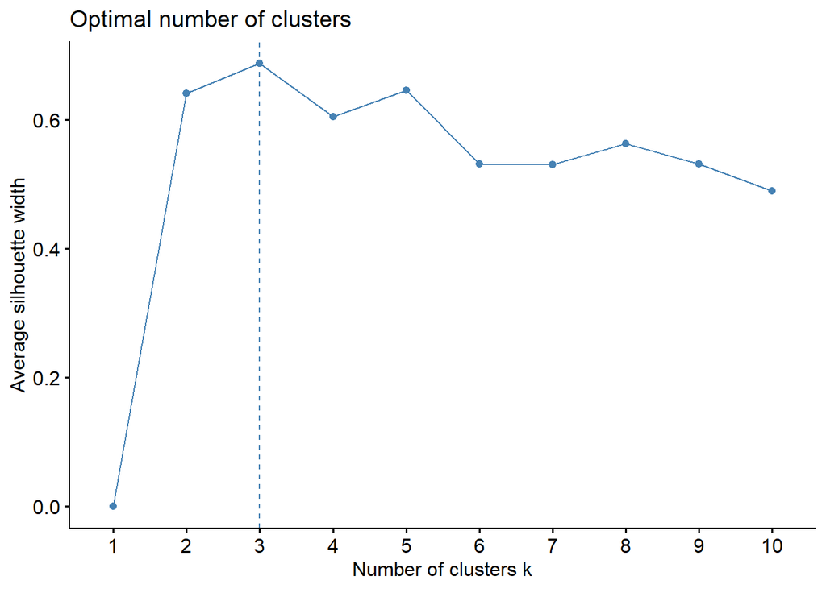

```r
# cálculo del score Silhouette
score_sil<- silhouette(clusters_kmedoids,daisy(rfm_clustering))

# cálculo del valor óptimo de k usando el score silhouette
fviz_nbclust(rfm_clustering,pam,method = 'silhouette',k.max = 10)
```

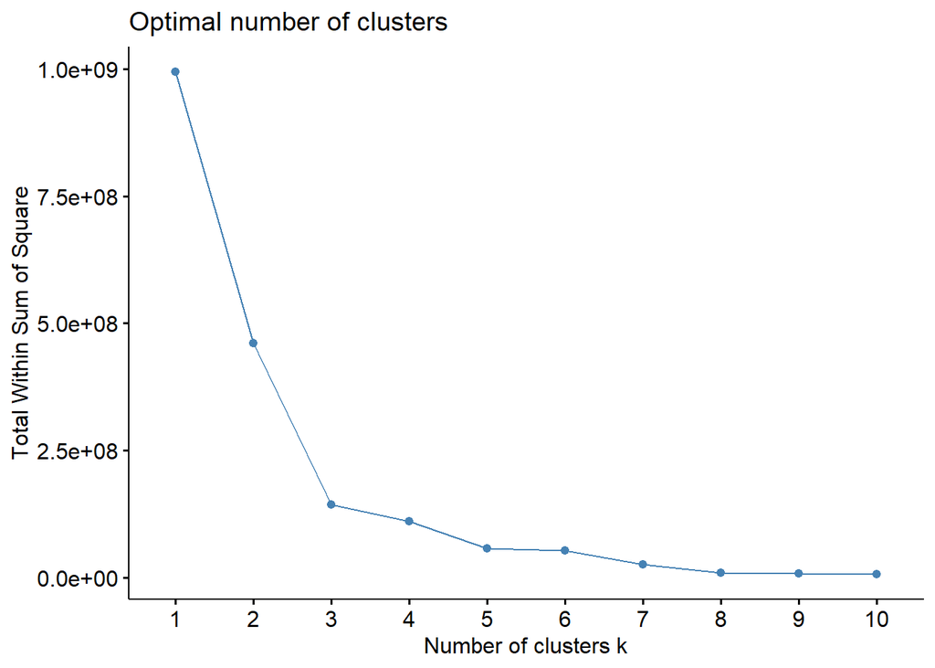

```r
# cálculo del valor óptimo de k usando el método del codo
fviz_nbclust(rfm_clustering,pam,method = 'wss',k.max = 10)
```

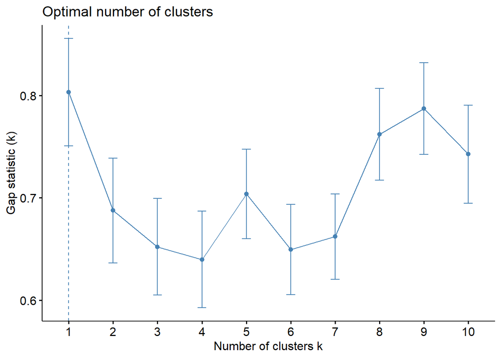

```r
# cálculo del valor óptimo de k usando la estadística gap
fviz_nbclust(rfm_clustering,pam,method = 'gap_stat',k.max = 10)
```

Como se muestra en los graficos anteriores, tanto el método de Silhoutte como el del Codo indican que el numero de clusters optimo es 3. El método de estadística de gap indica que este número sería 1. Para la creación de los clusters, vamos a utilizar 3, dado que no tiene sentido para los objetivos utilizar solo 1. Esta decisión se refuerza con el hecho que dos de los tres métodos retornan este valor.

```r
# cluster al que se asignó cada individuo
clusteres_medoids <- clusters_kmedoids$clustering
#clusteres_medoids
# Descripción de los clusters
medoids <- clusters_kmedoids$medoids
medoids
```

```
##      recency_days   amount
## [1,]           74   704.04
## [2,]           22 13219.74
## [3,]           22  4027.36
```

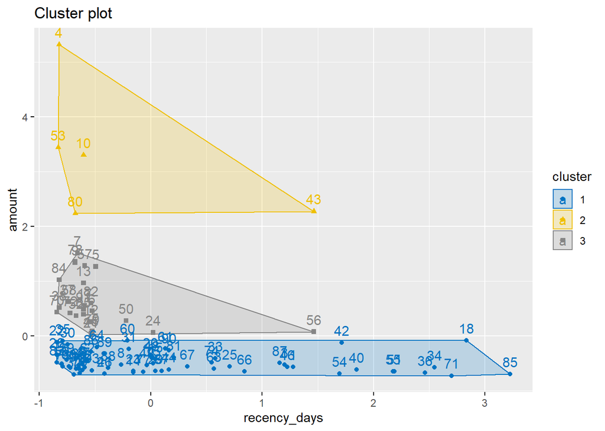

```r
# visualización de los clusters
#which(apply(rfm_clustering, 2, var)==0)
fviz_cluster(clusters_kmedoids,data=rfm_clustering,palette='jco')
```

##### Construcción del modelo #2 (Kmeans)

```r
clusters <- kmeans(rfm_clustering,3,nstart=20)
clusteres_kmeans <- clusters$cluster

# crear un data frame combinando el cluster asignado y los atributos originales
resultado_kmeans <- data.frame(clusters$cluster,rfm_clustering)
head(resultado_kmeans)
```

```
##   clusters.cluster recency_days   amount
## 1                1          194   582.73
## 2                1           21   825.80
## 3                1          187   729.54
## 4                3            2 19824.05
## 5                2           32  6572.11
## 6                2           29  3938.55
```

De los clusteres anteriores se puede observar como la variable recency no parece tener tanta significancia y los grupos tienen a tener una relación en cuanto al valor monetario invertido por cada cliente.

```r
#obtener cantidad de registros en cada cluster y los centroides
descClusters<- data.frame(clusters$size,clusters$centers)
descClusters
```

```
##   clusters.size recency_days     amount
## 1            69     95.86957   949.9414
## 2            20     19.15000  4849.3470
## 3             5     50.20000 13266.8480
```

###### Descripción del modelo obtenido (Incluya al menos un gráfico)

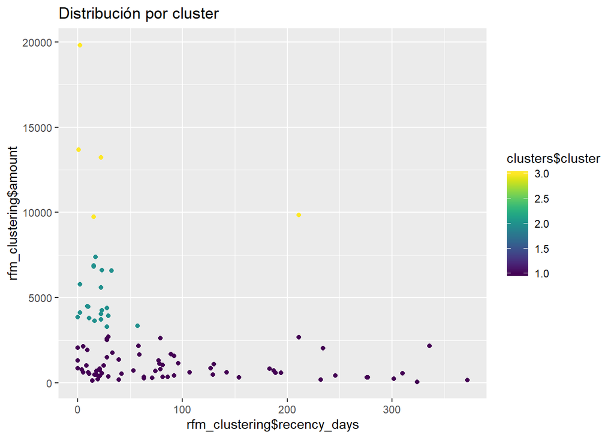

```r
ggplot(rfm_clustering,aes(rfm_clustering$recency_days,rfm_clustering$amount, color = clusters$cluster)) + geom_point()+ggtitle(label='Distribución por cluster') +
  scale_color_viridis(option = "D")
```

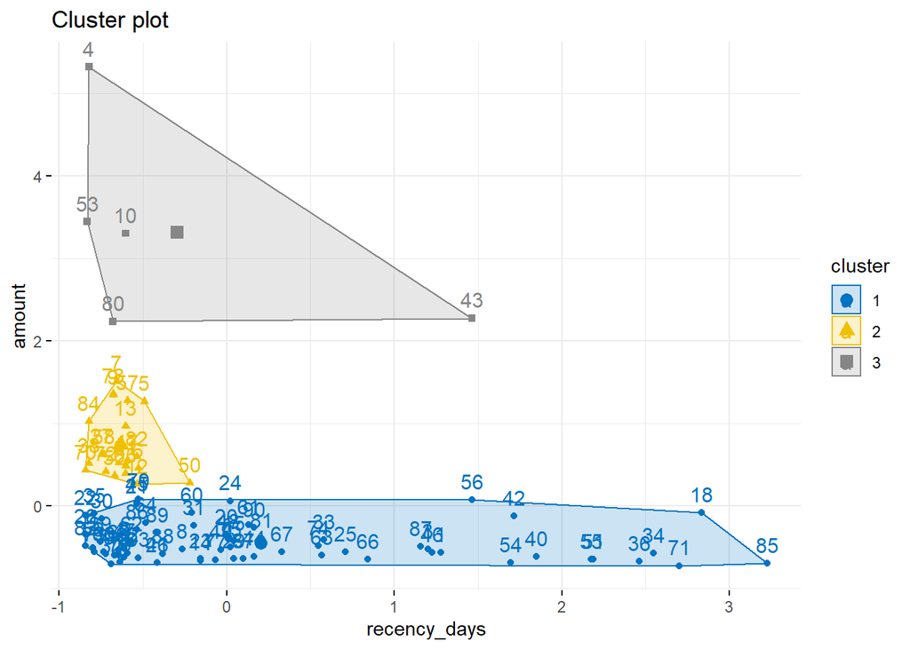

```r
# otra forma de visualizar los clusters
fviz_cluster(clusters,data=rfm_clustering,palette='jco',ggtheme = theme_minimal())
```

### Modelos de regresión

#### Selección de los parámetros

```r
compras <- datos_ge %>%
  group_by(InvoiceDay) %>%
  summarise_at(vars(Total),funs(sum(.)))
colnames(compras) <- c('Fecha','ventas')
kable(head(compras,10),"html", booktabs = T)%>%
  kable_styling(latex_options = "striped")
```

| Fecha | ventas |
| --- | --- |
| 2010-12-01 | 261.48 |
| 2010-12-02 | 155.35 |
| 2010-12-03 | 555.53 |
| 2010-12-05 | 2476.69 |
| 2010-12-06 | 196.44 |
| 2010-12-07 | 596.80 |
| 2010-12-08 | 522.70 |
| 2010-12-09 | 919.09 |
| 2010-12-10 | 2360.41 |
| 2010-12-13 | 12.45 |

```r
head(compras)
```

```
## # A tibble: 6 x 2
##   Fecha      ventas
##   <date>      <dbl>
## 1 2010-12-01   261.
## 2 2010-12-02   155.
## 3 2010-12-03   556.
## 4 2010-12-05  2477.
## 5 2010-12-06   196.
## 6 2010-12-07   597.
```

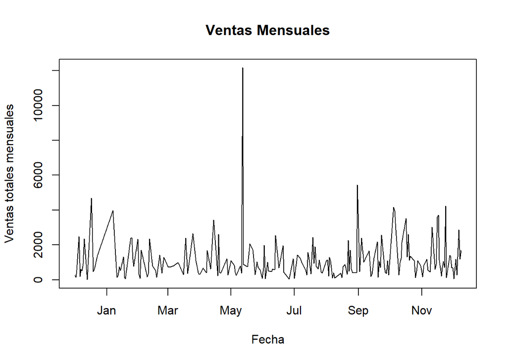

```r
plot(x = compras$Fecha, y = compras$ventas,
     main = 'Ventas Mensuales',
     xlab = 'Fecha',
     ylab = 'Ventas totales mensuales', type="l")
```

```r
compras_diferencia <- compras
compras_diferencia['ventas_previas'] <- shift(compras_diferencia$ventas,n=1,fill=0)
na.omit(compras_diferencia)
```

```
## # A tibble: 201 x 3
##    Fecha      ventas ventas_previas
##    <date>      <dbl>          <dbl>
##  1 2010-12-01  261.              0
##  2 2010-12-02  155.            261.
##  3 2010-12-03  556.            155.
##  4 2010-12-05 2477.            556.
##  5 2010-12-06  196.           2477.
##  6 2010-12-07  597.            196.
##  7 2010-12-08  523.            597.
##  8 2010-12-09  919.            523.
##  9 2010-12-10 2360.            919.
## 10 2010-12-13   12.4          2360.
## # ... with 191 more rows
```

```r
# se procede a calcular la diferencia

compras_diferencia['diferencia'] <- compras_diferencia$ventas - compras_diferencia$ventas_previas
head(compras_diferencia)
```

```
## # A tibble: 6 x 4
##   Fecha      ventas ventas_previas diferencia
##   <date>      <dbl>          <dbl>      <dbl>
## 1 2010-12-01   261.             0        261.
## 2 2010-12-02   155.           261.      -106.
## 3 2010-12-03   556.           155.       400.
## 4 2010-12-05  2477.           556.      1921.
## 5 2010-12-06   196.          2477.     -2280.
## 6 2010-12-07   597.           196.       400.
```

Al analizar el comportamiento de la diferencia de las ventas a lo largo del tiempo se observa que el comportamiento de las mismas no pareciera tener un comportamiento estacionario, sino que se mantiene constante a lo largo del anno, exceptuando el mes de mayo, el cual es el mes en que se celebra el dia de la madre en la mayoria de paises y puede ser un indicador del incremento de las ventas durante este mes.

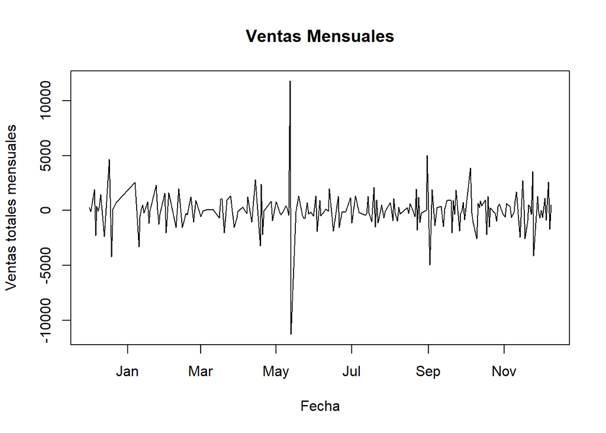

```r
plot(x = compras_diferencia$Fecha, y = compras_diferencia$diferencia,
     main = 'Ventas Mensuales',
     xlab = 'Fecha',
     ylab = 'Ventas totales mensuales', type="l")
```

```r
for (mes in 1:13){
  field_name = paste('lag_',toString(mes))
  compras_diferencia[field_name] <- shift(compras_diferencia$diferencia,n=mes,fill=0)
}

colnames(compras_diferencia) <- c('Fecha', 'Ventas', 'Ventas_previas', 'diff', 'Dic_Anno1','Ene_Anno2','Feb_Anno2','Mar_Anno2','Abr_Anno2','May_Anno2','Jun_Anno2','Jul_Anno2','Ago_Anno2','Sep_Anno2','Oct_Anno2','Nov_Anno2','Dic_Anno2')
```

```r
#Se particiona el dataset en entrenamiento y prueba.
sample = sample.split(compras_diferencia$diff, SplitRatio = .75)
entrenamiento = subset(compras_diferencia, sample == TRUE)
prueba  = subset(compras_diferencia, sample == FALSE)

summary(entrenamiento)
```

```
##      Fecha                Ventas         Ventas_previas
##  Min.   :2010-12-01   Min.   :   44.25   Min.   :    0.0
##  1st Qu.:2011-03-22   1st Qu.:  407.77   1st Qu.:  385.9
##  Median :2011-06-25   Median :  765.26   Median :  717.7
##  Mean   :2011-06-19   Mean   : 1200.73   Mean   : 1110.1
##  3rd Qu.:2011-09-20   3rd Qu.: 1355.91   3rd Qu.: 1297.3
##  Max.   :2011-12-09   Max.   :12165.25   Max.   :12165.2
##       diff             Dic_Anno1            Ene_Anno2
##  Min.   :-11284.05   Min.   :-11284.050   Min.   :-11284.05
##  1st Qu.:  -413.58   1st Qu.:  -600.175   1st Qu.:  -689.54
##  Median :   -37.44   Median :   -47.015   Median :   -37.44
##  Mean   :    90.64   Mean   :    -8.624   Mean   :    27.57
##  3rd Qu.:   777.06   3rd Qu.:   739.327   3rd Qu.:   801.31
##  Max.   : 11790.25   Max.   : 11790.250   Max.   : 11790.25
##    Feb_Anno2           Mar_Anno2           Abr_Anno2
##  Min.   :-11284.05   Min.   :-11284.05   Min.   :-11284.05
##  1st Qu.:  -611.10   1st Qu.:  -625.23   1st Qu.:  -681.49
##  Median :   -18.15   Median :   -47.02   Median :   -17.50
##  Mean   :    18.18   Mean   :   -47.05   Mean   :    10.35
##  3rd Qu.:   801.31   3rd Qu.:   671.99   3rd Qu.:   671.99
##  Max.   : 11790.25   Max.   : 11790.25   Max.   : 11790.25
##    May_Anno2           Jun_Anno2           Jul_Anno2
##  Min.   :-11284.05   Min.   :-11284.05   Min.   :-11284.05
##  1st Qu.:  -418.48   1st Qu.:  -552.87   1st Qu.:  -552.83
##  Median :     0.00   Median :   -50.42   Median :     0.00
##  Mean   :    54.64   Mean   :   -74.71   Mean   :    33.99
##  3rd Qu.:   726.72   3rd Qu.:   577.69   3rd Qu.:   777.06
##  Max.   : 11790.25   Max.   : 11790.25   Max.   : 11790.25
##    Ago_Anno2           Sep_Anno2           Oct_Anno2
##  Min.   :-11284.05   Min.   :-11284.05   Min.   :-11284.05
##  1st Qu.:  -661.93   1st Qu.:  -629.98   1st Qu.:  -418.48
##  Median :   -47.02   Median :   -18.15   Median :    -0.65
##  Mean   :   -46.36   Mean   :    38.44   Mean   :    38.31
##  3rd Qu.:   739.33   3rd Qu.:   875.95   3rd Qu.:   643.25
##  Max.   : 11790.25   Max.   : 11790.25   Max.   : 11790.25
##    Nov_Anno2          Dic_Anno2
##  Min.   :-11284.0   Min.   :-3293.80
##  1st Qu.:  -503.3   1st Qu.: -491.51
##  Median :     0.0   Median :    0.00
##  Mean   :    63.7   Mean   :   83.18
##  3rd Qu.:   777.1   3rd Qu.:  577.69
##  Max.   : 11790.2   Max.   :11790.25
```

```r
summary(prueba)
```

```
##      Fecha                Ventas        Ventas_previas
##  Min.   :2010-12-06   Min.   :  12.45   Min.   :  44.25
##  1st Qu.:2011-03-31   1st Qu.: 350.17   1st Qu.: 396.91
##  Median :2011-07-19   Median : 767.99   Median :1002.44
##  Mean   :2011-06-29   Mean   : 956.02   Mean   :1189.48
##  3rd Qu.:2011-10-16   3rd Qu.:1216.02   3rd Qu.:1692.03
##  Max.   :2011-12-05   Max.   :3612.12   Max.   :3720.96
##       diff           Dic_Anno1          Ene_Anno2
##  Min.   :-2585.6   Min.   :-4119.20   Min.   :-4971.02
##  1st Qu.:-1215.0   1st Qu.: -984.65   1st Qu.: -361.58
##  Median : -249.9   Median :   16.47   Median :  -44.20
##  Mean   : -233.5   Mean   :   48.66   Mean   :  -24.62
##  3rd Qu.:  677.8   3rd Qu.: 1184.59   3rd Qu.:  523.62
##  Max.   : 2810.0   Max.   : 2301.78   Max.   : 3532.41
##    Feb_Anno2          Mar_Anno2         Abr_Anno2          May_Anno2
##  Min.   :-4971.02   Min.   :-2430.4   Min.   :-4971.02   Min.   :-4971.0
##  1st Qu.: -796.85   1st Qu.: -571.5   1st Qu.: -425.25   1st Qu.: -919.6
##  Median :  -74.10   Median :   31.7   Median :  -37.66   Median : -101.7
##  Mean   :  -47.91   Mean   :  161.5   Mean   :  -29.13   Mean   : -147.0
##  3rd Qu.:  362.99   3rd Qu.:  924.9   3rd Qu.:  851.83   3rd Qu.:  805.0
##  Max.   : 5032.87   Max.   : 5032.9   Max.   : 3896.98   Max.   : 5032.9
##    Jun_Anno2         Jul_Anno2          Ago_Anno2         Sep_Anno2
##  Min.   :-4119.2   Min.   :-2584.27   Min.   :-3293.8   Min.   :-3217.6
##  1st Qu.: -642.6   1st Qu.: -576.18   1st Qu.: -323.3   1st Qu.: -522.9
##  Median :  106.4   Median :  -44.20   Median :  152.3   Median :    0.0
##  Mean   :  233.1   Mean   :  -73.33   Mean   :  164.0   Mean   : -110.6
##  3rd Qu.:  904.1   3rd Qu.:  510.94   3rd Qu.:  800.1   3rd Qu.:  381.1
##  Max.   : 5032.9   Max.   : 3532.41   Max.   : 2718.7   Max.   : 2584.6
##    Oct_Anno2          Nov_Anno2         Dic_Anno2
##  Min.   :-3293.80   Min.   :-3293.8   Min.   :-11284.0
##  1st Qu.: -586.05   1st Qu.: -756.6   1st Qu.:  -678.8
##  Median :    0.00   Median : -120.9   Median :     0.0
##  Mean   :  -29.45   Mean   : -173.4   Mean   :  -224.0
##  3rd Qu.:  846.72   3rd Qu.:  264.0   3rd Qu.:   825.9
##  Max.   : 3896.98   Max.   : 2810.0   Max.   :  3897.0
```

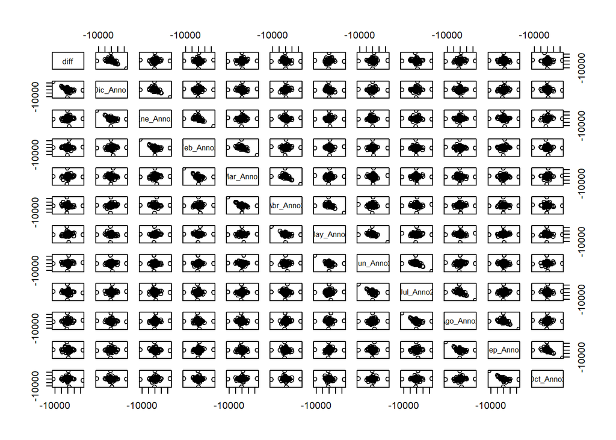

```r
pairs(entrenamiento[4:15])
```

Se utiliza la funcion cor para identificar la correlacion entre las variables de ventas de los diferentes meses de forma numérica.

```r
cor(entrenamiento[4:15])
```

```
##                  diff    Dic_Anno1   Ene_Anno2    Feb_Anno2   Mar_Anno2
## diff       1.00000000 -0.521738176  0.03662864 -0.024530059  0.06776071
## Dic_Anno1 -0.52173818  1.000000000 -0.53194817  0.052429439 -0.03424362
## Ene_Anno2  0.03662864 -0.531948173  1.00000000 -0.539180646  0.04608209
## Feb_Anno2 -0.02453006  0.052429439 -0.53918065  1.000000000 -0.51685889
## Mar_Anno2  0.06776071 -0.034243622  0.04608209 -0.516858885  1.00000000
## Abr_Anno2 -0.10433799  0.084884465 -0.01686807  0.007285036 -0.52277207
## May_Anno2  0.04416741 -0.126272595  0.03832184  0.007112057  0.01576264
## Jun_Anno2  0.07937581 -0.004646744 -0.01863880  0.037004664 -0.02198632
## Jul_Anno2 -0.09613908  0.089613391 -0.04880125 -0.006007852  0.05655800
## Ago_Anno2  0.07366846 -0.069806673  0.11671395 -0.095384402 -0.04360731
## Sep_Anno2 -0.03766202  0.082427464 -0.13834291  0.138063054 -0.05917598
## Oct_Anno2 -0.05591411 -0.056622155  0.10250524 -0.089325360  0.11101421
##              Abr_Anno2    May_Anno2    Jun_Anno2    Jul_Anno2    Ago_Anno2
## diff      -0.104337986  0.044167410  0.079375812 -0.096139082  0.073668456
## Dic_Anno1  0.084884465 -0.126272595 -0.004646744  0.089613391 -0.069806673
## Ene_Anno2 -0.016868065  0.038321841 -0.018638799 -0.048801247  0.116713946
## Feb_Anno2  0.007285036  0.007112057  0.037004664 -0.006007852 -0.095384402
## Mar_Anno2 -0.522772073  0.015762645 -0.021986317  0.056558004 -0.043607311
## Abr_Anno2  1.000000000 -0.502846547 -0.001047745 -0.010929822  0.066398904
## May_Anno2 -0.502846547  1.000000000 -0.485137490  0.007143771 -0.009713793
## Jun_Anno2 -0.001047745 -0.485137490  1.000000000 -0.536029368  0.041222528
## Jul_Anno2 -0.010929822  0.007143771 -0.536029368  1.000000000 -0.541694573
## Ago_Anno2  0.066398904 -0.009713793  0.041222528 -0.541694573  1.000000000
## Sep_Anno2 -0.046020609  0.067710035 -0.028113378  0.035539552 -0.527331941
## Oct_Anno2 -0.089994154 -0.025894534  0.056895436 -0.011314999  0.053824461
##             Sep_Anno2   Oct_Anno2
## diff      -0.03766202 -0.05591411
## Dic_Anno1  0.08242746 -0.05662216
## Ene_Anno2 -0.13834291  0.10250524
## Feb_Anno2  0.13806305 -0.08932536
## Mar_Anno2 -0.05917598  0.11101421
## Abr_Anno2 -0.04602061 -0.08999415
## May_Anno2  0.06771004 -0.02589453
## Jun_Anno2 -0.02811338  0.05689544
## Jul_Anno2  0.03553955 -0.01131500
## Ago_Anno2 -0.52733194  0.05382446
## Sep_Anno2  1.00000000 -0.54304492
## Oct_Anno2 -0.54304492  1.00000000
```

#### Modelo de Regresión lineal simple

```r
#Se crea la regresion lineal simple para la diferencia de las ventas
modelo.simple <- lm(diff ~ Dic_Anno1, data = entrenamiento)
#ver detalle del modelo
summary(modelo.simple)
```

```
##
## Call:
## lm(formula = diff ~ Dic_Anno1, data = entrenamiento)
##
## Residuals:
##     Min      1Q  Median      3Q     Max
## -6071.6  -740.0   -83.1   525.4 11484.7
##
## Coefficients:
##              Estimate Std. Error t value Pr(>|t|)
## (Intercept)  86.15875  135.13827   0.638    0.525
## Dic_Anno1    -0.51972    0.06985  -7.440 7.58e-12 ***
## ---
## Signif. codes:  0 '***' 0.001 '**' 0.01 '*' 0.05 '.' 0.1 ' ' 1
##
## Residual standard error: 1655 on 148 degrees of freedom
## Multiple R-squared:  0.2722, Adjusted R-squared:  0.2673
## F-statistic: 55.36 on 1 and 148 DF,  p-value: 7.579e-12
```

##### Evaluación Modelo de regresión lineal simple

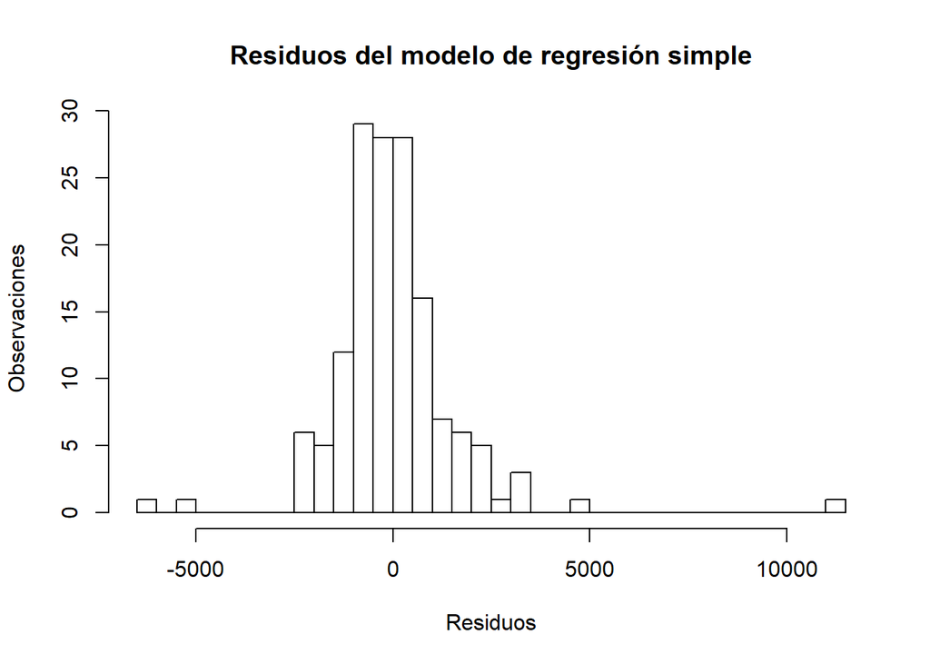

```r
#Distribución de los residuos del modelo basado en el peso
hist(modelo.simple$residuals,
     main= 'Residuos del modelo de regresión simple',
     xlab = 'Residuos',
     ylab = 'Observaciones',
     breaks = 50)
```

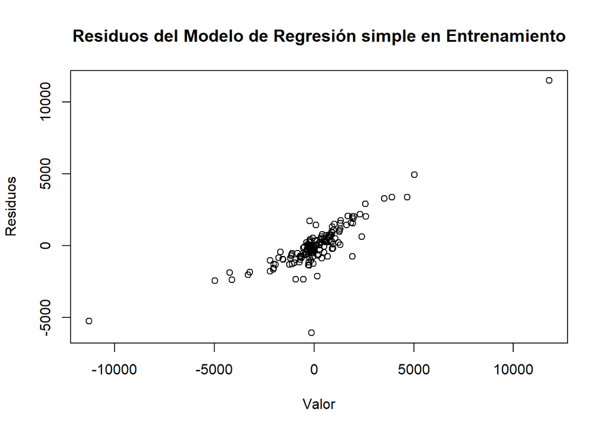

```r
# Ver distribución de los residuos del modelo
plot(x = entrenamiento$diff,
     y = modelo.simple$residuals,
     main = 'Residuos del Modelo de Regresión simple en Entrenamiento',
     xlab = 'Valor',
     ylab = 'Residuos')
```

```r
#Calcular el RMSE en Entrenamiento
entrenamiento$Prediccion <- predict(modelo.simple)
sqrt(mean((entrenamiento$diff - entrenamiento$Prediccion)^2))
```

```
## [1] 1644.012
```

```r
# predecir valores de diff en el conjunto de datos de prueba
prueba$Prediccion <- predict(modelo.simple, newdata = prueba)
#Calcular el RMSE en prueba
#sqrt(mean((prueba$diff - prueba$Prediccion)^2))

entrenamiento[,c(1,4,18)]
```

```
## # A tibble: 150 x 3
##    Fecha         diff Prediccion
##    <date>       <dbl>      <dbl>
##  1 2010-12-01   261.       86.2
##  2 2010-12-02  -106.      -49.7
##  3 2010-12-03   400.      141.
##  4 2010-12-05  1921.     -122.
##  5 2010-12-07   400.     1271.
##  6 2010-12-08   -74.1    -122.
##  7 2010-12-17  4678.     1306.
##  8 2010-12-19 -4221.    -2345.
##  9 2010-12-20   162.     2280.
## 10 2010-12-23   760.        1.92
## # ... with 140 more rows
```

```r
prueba[,c(1,4,18)]
```

```
## # A tibble: 51 x 3
##    Fecha         diff Prediccion
##    <date>       <dbl>      <dbl>
##  1 2010-12-06 -2280.       -912.
##  2 2010-12-09   396.        125.
##  3 2010-12-10  1441.       -120.
##  4 2010-12-13 -2348.       -663.
##  5 2011-01-12   106.        366.
##  6 2011-01-25    52.1     -1110.
##  7 2011-01-27  -408.        731.
##  8 2011-01-31  1564.        298.
##  9 2011-02-09 -1543.       -764.
## 10 2011-02-14 -1553.       -955.
## # ... with 41 more rows
```

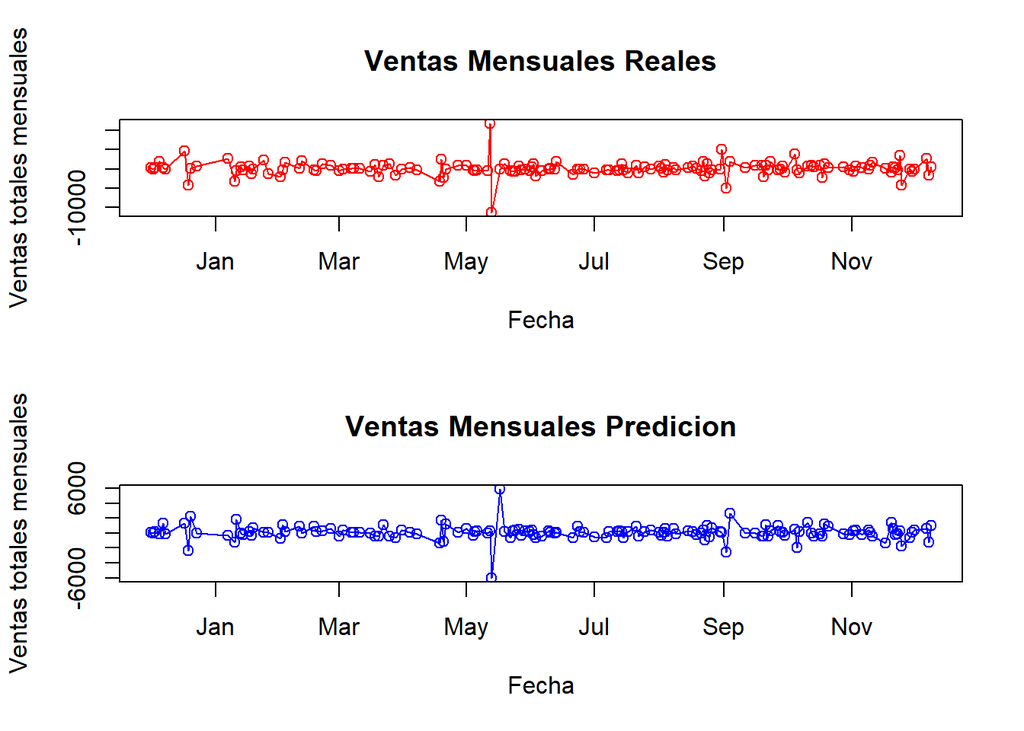

```r
par(mfrow = c(2,1))
plot(x = entrenamiento$Fecha, y = entrenamiento$diff,
     main = 'Ventas Mensuales Reales',
     xlab = 'Fecha',
     ylab = 'Ventas totales mensuales', type="o" ,col = "red")
lines(entrenamiento$Prediccion, type = "o", col = "blue")

plot(x = entrenamiento$Fecha, y = entrenamiento$Prediccion,
     main = 'Ventas Mensuales Predicion',
     xlab = 'Fecha',
     ylab = 'Ventas totales mensuales', type="o" ,col = "blue")
```

```r
#lines(entrenamiento$Prediccion, type = "o", col = "blue")
```